# SPSS dialog boxes for a descriptive analysis

Steve Simon

2002-06-21

This handout will show the SPSS dialog boxes that I used to create the examples in the descriptive data analysis handout. I will capitalize variable names, field names and menu picks for clarity.

**Compute frequency counts**

Select ANALYZE | DESCRIPTIVE STATISTICS | FREQUENCIES from the SPSS menu. You will see the following dialog box:

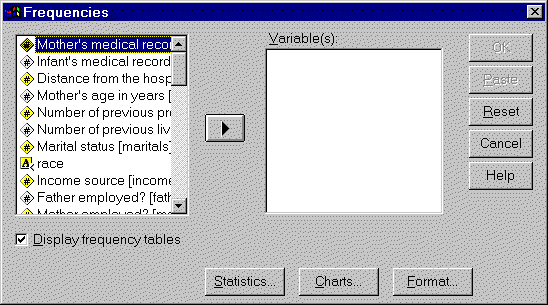

Click on RACE and then click on the right arrow button to add it to the VARIABLE(S) field.

**Find minimum and maximum values.**

Select ANALYZE | DESCRIPTIVE STATISTICS | DESCRIPTIVES from the SPSS menu. You will see the following dialog box.

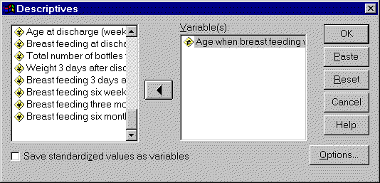

Select your variable in the list on the left and click on the arrow button to add it to the VARIABLE(S) field. You can repeat this for additional variables if needed.

**Compute cross tabulations**

Select ANALYZE | DESCRIPTIVE STATISTICS | CROSSTABS from the SPSS menu. You will see the following dialog box.

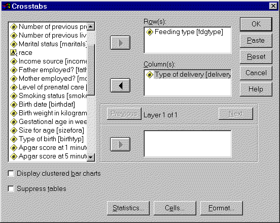

Select variables from the list on the left. Add one to the ROW(S) field and another to the COLUMN(S) field. Click on the OK button to continue.

To produce row percents, select ANALYZE | DESCRIPTIVE STATISTICS | CROSSTABS again. Notice that SPSS remembered your previous choices. How nice! Now click on the CELLS button to get the following dialog box.

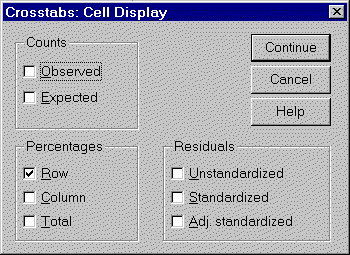

Check the ROW option. Now click on the CONTINUE button in this dialog box and the OK button in the previous dialog box.

**Drawing boxplots**

Select GRAPHS | BOXPLOT from the SPSS menu. You will see the following dialog box.

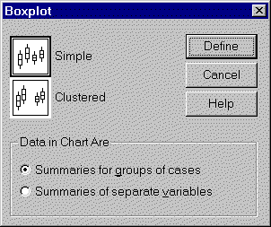

We will select the SIMPLE option and the SUMMARIES FOR GROUPS OF CASES option here. A good rule of thumb is to always try the default options first. You can always experiment with other options if needed, but the defaults in SPSS usually work well.

You would use the CLUSTERED option if you want to see separate box plots across the combination of two different categorical variables. You would select the SUMMARIES OF SEPARATE VARIABLES if you wanted box plots for several columns of data simultaneously.

When you click on the DEFINE button, you will see the following dialog box.

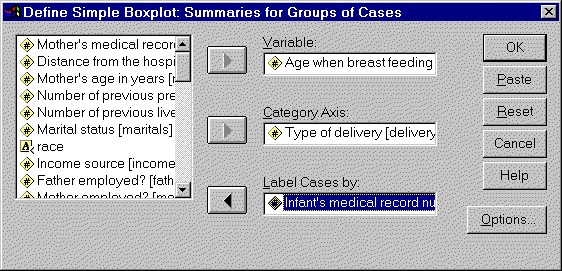

Select a continuous variable and add it to the VARIABLE field. Select a categorical variable and add it to the CATEGORY AXIS field. You can leave the LABEL CASES BY field blank if you like. The variable in this field provides labels for any outliers that might be found in the box plots. If the field is blank, SPSS labels outliers with the row number.

**Draw a scatterplot.**

Select GRAPHS | SCATTER from the SPSS menu. You will see the following dialog box.

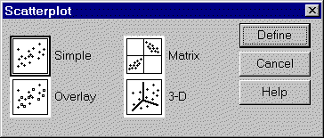

We will select the SIMPLE, the default option. You would select the OVERLAY option instead if you wanted to plot more than two columns of data simultaneously. You would select the 3-D option if you wanted to examine the relationship among three continuous variables simultaneously. These 3-D graphs look fancy, but they are often difficult to interpret. Another option which works for three (or even more) variables in the scatterplot matrix. This arranges graphs of all possible pairs of your data in a nice grid. When you click on the DEFINE button, you will see the following dialog box:

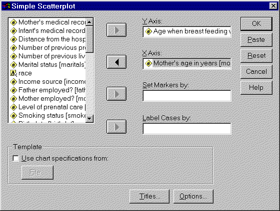

Select continuous variables for the Y-AXIS field and the X-AXIS field. The remaining two fields are optional. If you place a categorical variable in the SET MARKERS BY field, SPSS will use different marks for each level of your categorical variable. If you place a variable in the LABEL CASES BY field, thenvalues of that variable will appear as labels by each data point. With a graph like ours with 87 points, those labels would make our graph far too cluttered.

You may wish to modify or customize the graph that SPSS produces. To make changes, double click on the graph. You will get a chart editor window that looks like the following.

[figure not shown]

For example, the points displayed in this graph are too small and the wrong shape. To modify this, select FORMAT | MARKER from the SPSS menu. You will see the following dialog box.

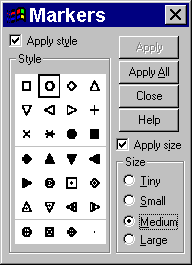

Select the open circle marker and the MEDIUM size option. Then click on the APPLY ALL button. If you like this choice, click on the CLOSE button in the above dialog box and select FILE | CLOSE from the chart editor window. The modified graph will appear in the SPSS output window.